# Introducción a las ciencias de la computación *y programación en Python*

## Algoritmos de búsqueda y ordenamiento

[figure not shown]

### Rodrigo Chang

#### Banco de Guatemala

## Abstract

### "*An algorithm must be seen to be believed.*" **Donald Knuth**

- Algoritmos de búsqueda
  - Búsqueda lineal.
  - Búsqueda binaria por bisección.
- Algoritmos de ordenamiento
  - Método de burbuja
  - *Merge sort*.
  - *Quicksort*.

## Algoritmos de búsqueda

- Método para encontrar un ítem específico en una colección de elementos:
  - La colección puede ser implícita.
    - Por ejemplo: encontrar una raíz cuadrada es un problema de búsqueda.
    - Métodos:
      - Enumeración exhaustiva,
      - método de bisección,
      - método de Newton.
  - La colección puede ser explícita.
    - Por ejemplo: buscar la calificación de un estudiante en una lista.

## Algoritmos de búsqueda

- Búsqueda lineal
  - Por **fuerza bruta**.
  - La lista puede no estar ordenada.
- Búsqueda por bisección
  - La lista debe estar ordenada para que funcione.
  - Vimos dos implementaciones de este algoritmo.

## Búsqueda lineal en lista desordenada

```python
def linear_search(L, e):
    found = False
    for i in range(len(L)):
        if e == L[i]:
            found = True
    return found
```

- Se debe buscar a través de todos los elementos para decidir que el elemento está ausente.
- $O(\text{len}(L))$ para el ciclo $\times O(1)$ para determinar `if e == L[i]`
- Complejidad general: $O(n)$, donde $n = \text{L}$.

## Búsqueda lineal en lista *ordenada* (recapitulación)

```python
def search(L, e):
    for i in range(len(L)):
        if L[i] == e:
            return True
        if L[i] > e:
            return False
    return False
```

- Buscamos solamente hasta alcanzar un número mayor a `e`.
- $O(\text{len}(L))$ para el ciclo $\times O(1)$ para determinar `if e == L[i]`
- Complejidad general: $O(n)$, donde $n = \text{L}$.

## Búsqueda binaria (recapitulación)

- Con una **lista ordenada**:
1. Escogemos un índice `i` que divide la lista a la mitad.
2. Revisamos si `L[i] == e`:
3. Si no, revisamos si `L[i]` es mayor o menor que `e`
4. Dependiendo de la respuesta, buscamos a la izquierda o derecha de `L`.
- Aproximación de **divide y conquista**.
  - Obtenemos una versión más pequeña del problema.

## Búsqueda binaria (bisección)

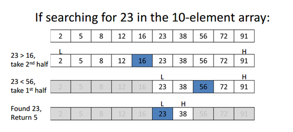

- En cada paso, la lista se divide a la mitad.
- Terminamos de ver la lista cuando $n/2^i = 1$, es decir, $i = \log_{2} n$.
- Complejidad del problema es $O(\log n)$, donde $n = \text{len}(L)$.

## Implementación 2

- Evitamos copiar la lista en cada llamada.
- Para esto, llevamos registro de los índices del rango en el cual vamos a buscar.
  - Ingenioso, ¿verdad?
- La complejidad de la recursión seguirá siendo $O(\log n)$, donde $n = \text{L}$.

## Implementación 2

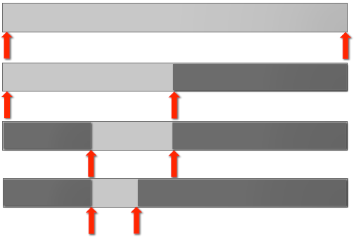

- Aún reduce el tamaño del problema en un factor de 2 en cada paso.
- Pero solamente se lleva registro de qué índices `low` y `high` se deben revisar para **evitar** copiar la lista.
- Complejidad de la recursión es nuevamente $O(\log n)$, donde $n=\text{len}(L)$.

## Implementación 2

```python
def bisect_search2(L, e):
    def bisect_search_helper(L, e, low, high):
        if high == low:
            return L[low] == e

        mid = (low + high)//2
        if L[mid] == e:
            return True
        elif L[mid] > e:
            if low == mid: #nothing left to search
                return False
            else:
                return bisect_search_helper(L, e, low, mid - 1)
        else:
            return bisect_search_helper(L, e, mid + 1, high)

    # Cuerpo de la función
    if len(L) == 0:
        return False
    else:
        return bisect_search_helper(L, e, 0, len(L) - 1)
```

- Ver en Python Tutor

## Implementación 2

- Al utilizar la función `helper` evitamos la copia.
  - Pasamos índices `low` y `high` en cada llamada.
- Como la lista no se copia, se pasa por "referencia" hacia las llamadas sucesivas tenemos $O(1)$ en las nuevas llamadas.
- Ahora $O(\log n)*O(1) = O(\log n)$

## Búsqueda en una lista *ordenada*

- Con **búsqueda lineal**, la complejidad es $O(n)$.
- Con **búsqueda binaria**, se puede buscar un elemento con $O(\log n)$.
  - Es necesario que la **lista esté ordenada**.
- ¿Por qué hace sentido **ordenar primero y después buscar**?
  - Ordenar **nunca tiene complejidad menor a $O(n)$**, es más eficiente ordenar primero para **amortizar el costo** sobre muchas búsquedas.
  - Si $K$ es el número de búsquedas: $$\text{ORDENAR} + K*O(\log n) < K * O(n)$$
    - Para $K$ muy grande, el tiempo de $\text{ORDENAR}$ se vuelve **irrelevante**, si el costo de ordenar es suficientemente pequeño.

## Algoritmos de ordenamiento

- Queremos ordenar **eficientemente** una lista de entradas (típicamente números).
- Veamos algunos métodos.

## Monkey sort

- Bogosort (alias *permutation sort*, *stupid sort*) es un algoritmo de ordenamiento aleatorio.
- Ordenar una pila de cartas:
  - Arrojarlas al aire y recogerlas
  - ¿Están ordenadas?
  - Si no, repetir.
- Mejor caso: $O(n)$ para revisar si la lista está ordenada.
- Peor de los casos: $O(.)$ indeterminado (¡muy mala suerte!)

## Método de burbuja

- Compara **pares consecutivos** de elementos.
- Intercambia los elementos para que el menor vaya primero.
- Cuando se llega al final de la lista, **empezamos otra vez**.
- Paramos hasta que no existan intercambios.

[figure not shown]

## Complejidad del método de burbuja

```python
def bubble_sort(L):
    swap = False
    while not swap:
        swap = True
        for j in range(1, len(L)):
            if L[j-1] > L[j]:
                swap = False
                temp = L[j]
                L[j] = L[j-1]
                L[j-1] = temp
```

- Ciclo interior para las **comparaciones**.
- Ciclo exterior para los los múltiples **pasos**
- Complejidad $O(n^2)$ donde $n = \text{len}(L)$
  - $\text{len}(L)-1$ comparaciones y $\text{len}(L)-1 $ barridas.

## *Merge sort*

- Utilizamos **"divide y conquista"**.
- Si la lista es de largo 0 o 1, ¡ya está ordenada!
- Si tiene más elementos, la **dividimos** en dos listas y ordenamos cada una.
- **Combinamos** las sublistas ordenadas.
  - Miramos el primer elemento de cada una, ponemos el menor al final de los resultados ordenados.
  - Cuando una lista está vacía, copiamos el resto de la otra lista.

## *Merge sort*

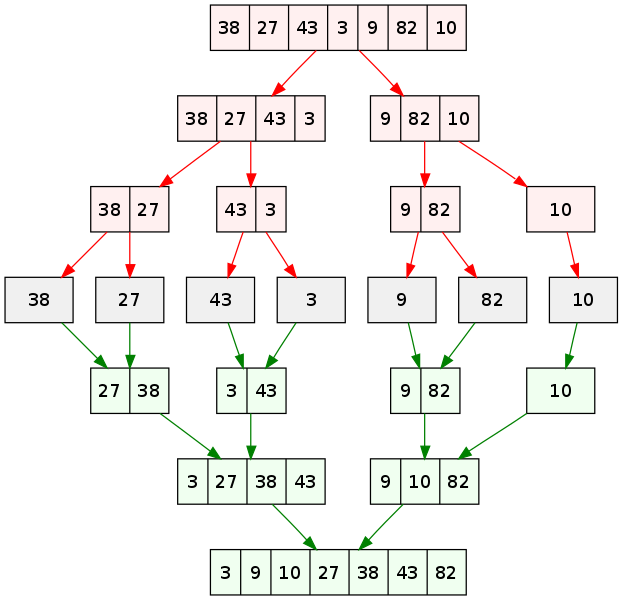

## *Merge sort*

```python
def merge(left, right):
    result = []
    i,j = 0,0
    while i < len(left) and j < len(right):
        if left[i] < right[j]:
            result.append(left[i])
            i += 1
        else:
            result.append(right[j])
            j += 1
    while (i < len(left)):
        result.append(left[i])
        i += 1
    while (j < len(right)):
        result.append(right[j])
        j += 1
    return result
```

```python
L1 = [1,5,12,18,19,20]
L2 = [2,3,4,17]
merge(L1, L2)
```

```
[1, 2, 3, 4, 5, 12, 17, 18, 19, 20]
```

## *Merge sort*

- Se divide la lista sucesivamente en mitades.
- Se **conquistan** piezas más pequeñas antes de las piezas más grandes.

```python
def merge_sort(L):
    # Caso base
    if len(L) < 2:
        return L[:]
    else:
        middle = len(L)//2
        # Divide
        left = merge_sort(L[:middle])
        right = merge_sort(L[middle:])
        # Vencerás con el paso de merge
        return merge(left, right)
```

```python
L = [1,5,12,18,19,20,2,3,4,17]
merge_sort(L)
```

```
[1, 2, 3, 4, 5, 12, 17, 18, 19, 20]
```

## Complejidad de *merge sort*

- En el **primer nivel de recursión**:
  - $n/2$ elementos en cada lista
  - $O(n) + O(n) = O(n)$, donde $n=\text{len}(L)$
- En el **segundo nivel de recursión**:
  - $n/4$ elementos en cada lista
  - Dos uniones $\rightarrow O(n)$, donde $n=\text{len}(L)$.
- Cada nivel de recursión es $O(n)$
- Al dividir la lista por la mitad con cada llamada tenemos $O(\log n)$ por cada llamada recursiva.
- Complejidad $O(n\log n)$, donde $n=\text{len}(L)$.

## *Quicksort*

- **Divide y vencerás**
- Se escoge un **pivote** para dividir la lista en dos sublistas.
  - La lista izquierda tiene los elementos **menores** que el pivote.
  - La lista derecha tiene los elementos **mayores** que el pivote.
- Recursivamente, se ordenan las dos sublistas
- Se combinan los resultados.

## *Quicksort*

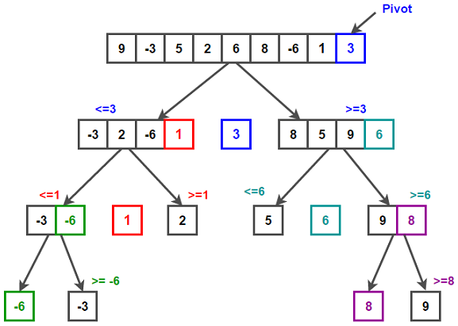

## *Quicksort*

```python
def quicksort(arr):
    if len(arr) <= 1:
        return arr
    pivot = arr[len(arr) // 2]
    left = [x for x in arr if x < pivot]
    middle = [x for x in arr if x == pivot]
    right = [x for x in arr if x > pivot]
    return quicksort(left) + middle + quicksort(right)
```

```python
quicksort([3,6,8,10,1,2,1])
```

```
[1, 1, 2, 3, 6, 8, 10]
```

## Complejidad del *quicksort*

- Depende de la posición del pivote elegido.
  - En el mejor caso termina al centro de la lista, dividiéndola en dos sublistas de igual tamaño. En este caso, *quicksort* es $O(n \log n)$.
  - En el peor caso, el pivote termina en un extremo. En este caso, *quicksort* es $O(n^2)$.
  - En promedio, entonces $O(n\log n)$.
- Existen optimizaciones que se enfocan en la elección del pivote.

## Algoritmos de ordenamiento

- *Bogosort*: $O(\cdot)$ no acotado
- Burbuja: $O(n^2)$
- *Merge sort*: $O(n\log n)$
- *Quicksort*: $O(n \log n)$ en promedio

# FIN

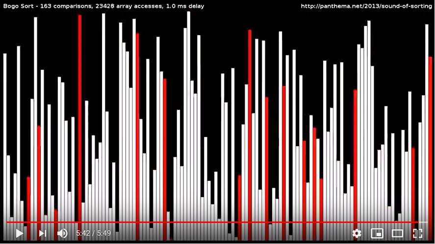

[15 Sorting Algorithms in 6 Minutes](https://www.youtube.com/watch?v=kPRA0W1kECg)